# INFO370 PS4

*Name*: Bridget Leonard \ *Collaborators*: 1) Saimanasvi Charugundla

```python
import numpy as np
import matplotlib.pyplot as plt
import pandas as pd
import seaborn as sns
import statsmodels.formula.api as smf
```

# Q1.When will we hit 2C of global warming?

### 1

```python
hadcrut = pd.read_csv("../data/hadcrut-5.0.1.0-annual.csv.bz2")
hadcrut.shape
```

```
(173, 4)
```

```python
hadcrut.head()
```

|  | Time | Anomaly (deg C) | Lower confidence limit (2.5%) | Upper confidence limit (97.5%) |
| --- | --- | --- | --- | --- |
| 0 | 1850 | -0.417659 | -0.589203 | -0.246115 |
| 1 | 1851 | -0.233350 | -0.411868 | -0.054832 |
| 2 | 1852 | -0.229399 | -0.409382 | -0.049416 |
| 3 | 1853 | -0.270354 | -0.430009 | -0.110700 |
| 4 | 1854 | -0.291630 | -0.432824 | -0.150436 |

### 2

```python
hadcrut = hadcrut.rename({"Anomaly (deg C)":"tempAnomaly"}, axis=1)
hadcrut.head()
```

|  | Time | tempAnomaly | Lower confidence limit (2.5%) | Upper confidence limit (97.5%) |
| --- | --- | --- | --- | --- |
| 0 | 1850 | -0.417659 | -0.589203 | -0.246115 |
| 1 | 1851 | -0.233350 | -0.411868 | -0.054832 |
| 2 | 1852 | -0.229399 | -0.409382 | -0.049416 |
| 3 | 1853 | -0.270354 | -0.430009 | -0.110700 |
| 4 | 1854 | -0.291630 | -0.432824 | -0.150436 |

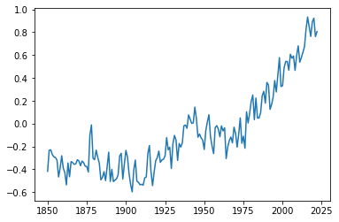

```python
_ = plt.plot(hadcrut.Time, hadcrut.tempAnomaly)
```

### 1

```python
bl = np.mean(hadcrut.tempAnomaly[hadcrut.Time <= 1900])
bl
```

```
-0.3565021707254903
```

### 2

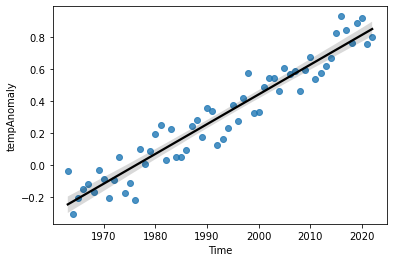

```python
_ = sns.regplot(x=hadcrut.Time[hadcrut.Time >= 1963], y=hadcrut.tempAnomaly[hadcrut.Time >= 1963], line_kws={"color":"black"})
```

### 3

```python
hadcrut["anomalyBL"] = hadcrut["tempAnomaly"] - bl
hadcrut.head()
```

|  | Time | tempAnomaly | Lower confidence limit (2.5%) | Upper confidence limit (97.5%) | anomalyBL |
| --- | --- | --- | --- | --- | --- |
| 0 | 1850 | -0.417659 | -0.589203 | -0.246115 | -0.061157 |
| 1 | 1851 | -0.233350 | -0.411868 | -0.054832 | 0.123152 |
| 2 | 1852 | -0.229399 | -0.409382 | -0.049416 | 0.127103 |
| 3 | 1853 | -0.270354 | -0.430009 | -0.110700 | 0.086148 |
| 4 | 1854 | -0.291630 | -0.432824 | -0.150436 | 0.064872 |

### 4

```python
hadcrut["relativeYear"] = hadcrut["Time"] - 2000
hadcrut.head()
```

|  | Time | tempAnomaly | Lower confidence limit (2.5%) | Upper confidence limit (97.5%) | anomalyBL | relativeYear |
| --- | --- | --- | --- | --- | --- | --- |
| 0 | 1850 | -0.417659 | -0.589203 | -0.246115 | -0.061157 | -150 |
| 1 | 1851 | -0.233350 | -0.411868 | -0.054832 | 0.123152 | -149 |
| 2 | 1852 | -0.229399 | -0.409382 | -0.049416 | 0.127103 | -148 |
| 3 | 1853 | -0.270354 | -0.430009 | -0.110700 | 0.086148 | -147 |
| 4 | 1854 | -0.291630 | -0.432824 | -0.150436 | 0.064872 | -146 |

```python
recent = hadcrut[hadcrut.Time >= 1963]
recent.head()
```

|  | Time | tempAnomaly | Lower confidence limit (2.5%) | Upper confidence limit (97.5%) | anomalyBL | relativeYear |
| --- | --- | --- | --- | --- | --- | --- |
| 113 | 1963 | -0.036806 | -0.090570 | 0.016958 | 0.319696 | -37 |
| 114 | 1964 | -0.305867 | -0.349492 | -0.262241 | 0.050635 | -36 |
| 115 | 1965 | -0.204388 | -0.253574 | -0.155202 | 0.152114 | -35 |
| 116 | 1966 | -0.148885 | -0.198392 | -0.099377 | 0.207618 | -34 |
| 117 | 1967 | -0.117516 | -0.160625 | -0.074408 | 0.238986 | -33 |

```python
m = smf.ols("anomalyBL ~ relativeYear", data=recent).fit()
m.summary()
```

OLS Regression Results

| Dep. Variable: | anomalyBL | R-squared: | 0.920 |
| --- | --- | --- | --- |
| Model: | OLS | Adj. R-squared: | 0.918 |
| Method: | Least Squares | F-statistic: | 665.3 |
| Date: | Wed, 08 Feb 2023 | Prob (F-statistic): | 1.80e-33 |
| Time: | 21:36:28 | Log-Likelihood: | 55.935 |
| No. Observations: | 60 | AIC: | -107.9 |
| Df Residuals: | 58 | BIC: | -103.7 |
| Df Model: | 1 |  |  |
| Covariance Type: | nonrobust |  |  |

|  | coef | std err | t | P>\|t\| | [0.025 | 0.975] |
| --- | --- | --- | --- | --- | --- | --- |
| Intercept | 0.7996 | 0.014 | 58.663 | 0.000 | 0.772 | 0.827 |
| relativeYear | 0.0186 | 0.001 | 25.794 | 0.000 | 0.017 | 0.020 |

| Omnibus: | 2.154 | Durbin-Watson: | 1.718 |
| --- | --- | --- | --- |
| Prob(Omnibus): | 0.341 | Jarque-Bera (JB): | 1.385 |
| Skew: | 0.061 | Prob(JB): | 0.500 |
| Kurtosis: | 2.266 | Cond. No. | 20.6 |

Notes:  
[1] Standard Errors assume that the covariance matrix of the errors is correctly specified.

R-squared is 0.92. This tells us that the model explains 92% of the variation in the data. This indicates that we have a good model since it is highly predictive.

### 5

The intercept means that if time = 0, which in this case is the year 2000, the temperature anomaly is 0.7996 (deg C) above baseline. The slope (relativeYear) indicates that the cases where relative year is larger by one unit have temperature anomaly larger by 0.0186 units (on average).

It is very unlikely (p < 0.001) that'd we'd observe a slope this extreme if H0 is true. Thus, the slope is statistically significant.

### 6

```python
m = smf.ols("anomalyBL ~ Time", data=recent).fit()
m.summary()
```

OLS Regression Results

| Dep. Variable: | anomalyBL | R-squared: | 0.920 |
| --- | --- | --- | --- |
| Model: | OLS | Adj. R-squared: | 0.918 |
| Method: | Least Squares | F-statistic: | 665.3 |
| Date: | Wed, 08 Feb 2023 | Prob (F-statistic): | 1.80e-33 |
| Time: | 21:36:30 | Log-Likelihood: | 55.935 |
| No. Observations: | 60 | AIC: | -107.9 |
| Df Residuals: | 58 | BIC: | -103.7 |
| Df Model: | 1 |  |  |
| Covariance Type: | nonrobust |  |  |

|  | coef | std err | t | P>\|t\| | [0.025 | 0.975] |
| --- | --- | --- | --- | --- | --- | --- |
| Intercept | -36.4592 | 1.439 | -25.335 | 0.000 | -39.340 | -33.578 |
| Time | 0.0186 | 0.001 | 25.794 | 0.000 | 0.017 | 0.020 |

| Omnibus: | 2.154 | Durbin-Watson: | 1.718 |
| --- | --- | --- | --- |
| Prob(Omnibus): | 0.341 | Jarque-Bera (JB): | 1.385 |
| Skew: | 0.061 | Prob(JB): | 0.500 |
| Kurtosis: | 2.266 | Cond. No. | 2.29e+05 |

Notes:  
[1] Standard Errors assume that the covariance matrix of the errors is correctly specified.  
[2] The condition number is large, 2.29e+05. This might indicate that there are  
strong multicollinearity or other numerical problems.

The intercept is statistically significant since our p-value (<0.001) is less than 0.01

```python
m = smf.ols("anomalyBL ~ relativeYear", data=recent).fit()
m.summary()
```

OLS Regression Results

| Dep. Variable: | anomalyBL | R-squared: | 0.920 |
| --- | --- | --- | --- |
| Model: | OLS | Adj. R-squared: | 0.918 |
| Method: | Least Squares | F-statistic: | 665.3 |
| Date: | Wed, 08 Feb 2023 | Prob (F-statistic): | 1.80e-33 |
| Time: | 21:36:31 | Log-Likelihood: | 55.935 |
| No. Observations: | 60 | AIC: | -107.9 |
| Df Residuals: | 58 | BIC: | -103.7 |
| Df Model: | 1 |  |  |
| Covariance Type: | nonrobust |  |  |

|  | coef | std err | t | P>\|t\| | [0.025 | 0.975] |
| --- | --- | --- | --- | --- | --- | --- |
| Intercept | 0.7996 | 0.014 | 58.663 | 0.000 | 0.772 | 0.827 |
| relativeYear | 0.0186 | 0.001 | 25.794 | 0.000 | 0.017 | 0.020 |

| Omnibus: | 2.154 | Durbin-Watson: | 1.718 |
| --- | --- | --- | --- |
| Prob(Omnibus): | 0.341 | Jarque-Bera (JB): | 1.385 |
| Skew: | 0.061 | Prob(JB): | 0.500 |
| Kurtosis: | 2.266 | Cond. No. | 20.6 |

Notes:  
[1] Standard Errors assume that the covariance matrix of the errors is correctly specified.

(B) If we use relative year to the year 2000, we center our dataset at the year 2000 and effectively provide a zero point for our indepedent variable. This makes the model much more interpretable, that is the intercept reflects the predicted temperature anomaly in the year 2000.

The intercept is statistically significant since our p-value (<0.001) is less than 0.01

### 7

```python
anom2022 = 0.7996 + (0.0186*22)
anom2022
```

```
1.2087999999999999
```

### 8

```python
def tempAnom(C):
    x = (C - 0.7996) / 0.0186
    return(x + 2000)
```

```python
tempAnom(1.5)
```

```
2037.6559139784947
```

```python
tempAnom(2)
```

```
2064.537634408602
```

The model predicts that the temperature anomaly will hit 1.5C over the pre-industrial baseline in 2038, and will hit 2C over the baseline in 2065.

### 9

Looking back to the original of the temperature anomaly from 1850 to now (1.1.2), it seems that the global warming may also fit a power or exponential regression model since the temperature anomaly appears to start increasing at a faster rate in more recent years. If this is true, we could cross the 1.5/2C thresholds faster than expected since the progression of global warming is not linear and thus is actually accelerating faster than predicted by this model. I think seeing how these models fit the data could improve our predictions. Perhaps also using mixed models to add in more variables (like C02 emissions) could increase our predictive power.

# Q2.How Is Basketball Game Score Calculated?

### 2.1

```python
harden = pd.read_csv("../data/harden-21-22.csv.bz2")
harden.shape
```

```
(83, 30)
```

```python
harden.head()
```

|  | Rk | G | Date | Age | Tm | Unnamed: 5 | Opp | Unnamed: 7 | GS | MP | ... | DRB | TRB | AST | STL | BLK | TOV | PF | PTS | GmSc | +/- |
| --- | --- | --- | --- | --- | --- | --- | --- | --- | --- | --- | --- | --- | --- | --- | --- | --- | --- | --- | --- | --- | --- |
| 0 | 1 | 1.0 | 2021-10-19 | 32-054 | BRK | @ | MIL | L (-23) | 1 | 30:38 | ... | 5 | 8 | 8 | 1 | 2 | 4 | 3 | 20 | 17.6 | -20 |
| 1 | 2 | 2.0 | 2021-10-22 | 32-057 | BRK | @ | PHI | W (+5) | 1 | 38:25 | ... | 6 | 7 | 8 | 2 | 0 | 5 | 0 | 20 | 15.6 | -1 |
| 2 | 3 | 3.0 | 2021-10-24 | 32-059 | BRK | NaN | CHO | L (-16) | 1 | 33:09 | ... | 5 | 7 | 8 | 1 | 1 | 8 | 5 | 15 | 6.4 | -15 |
| 3 | 4 | 4.0 | 2021-10-25 | 32-060 | BRK | NaN | WAS | W (+14) | 1 | 30:25 | ... | 5 | 6 | 9 | 1 | 1 | 2 | 1 | 14 | 11.9 | +6 |
| 4 | 5 | 5.0 | 2021-10-27 | 32-062 | BRK | NaN | MIA | L (-13) | 1 | 35:36 | ... | 7 | 7 | 7 | 1 | 1 | 4 | 3 | 14 | 10.7 | -12 |

5 rows × 30 columns

### 2.2

```python
# If Harden didn't play "G" is NaN
```

```python
harden.G.isna().sum()
```

```
18
```

Harden didn't play 18 games out of the 83 games, so he played 65 games.

```python
harden = harden.dropna(subset=["G"])
harden.shape
```

```
(65, 30)
```

### 2.3

```python
harden.sample(10)
```

|  | Rk | G | Date | Age | Tm | Unnamed: 5 | Opp | Unnamed: 7 | GS | MP | ... | DRB | TRB | AST | STL | BLK | TOV | PF | PTS | GmSc | +/- |
| --- | --- | --- | --- | --- | --- | --- | --- | --- | --- | --- | --- | --- | --- | --- | --- | --- | --- | --- | --- | --- | --- |
| 18 | 19 | 19.0 | 2021-11-24 | 32-090 | BRK | @ | BOS | W (+19) | 1 | 35:55 | ... | 6 | 7 | 11 | 2 | 0 | 3 | 4 | 20 | 19.7 | +29 |
| 66 | 67 | 51.0 | 2022-03-13 | 32-199 | PHI | @ | ORL | W (+2) | 1 | 44:04 | ... | 5 | 6 | 6 | 3 | 0 | 3 | 1 | 26 | 19.9 | +4 |
| 46 | 47 | 42.0 | 2022-01-25 | 32-152 | BRK | NaN | LAL | L (-10) | 1 | 38:22 | ... | 9 | 12 | 11 | 2 | 1 | 6 | 1 | 33 | 29.4 | -12 |
| 37 | 38 | 34.0 | 2022-01-09 | 32-136 | BRK | NaN | SAS | W (+2) | 1 | 43:57 | ... | 7 | 7 | 12 | 1 | 1 | 6 | 3 | 26 | 21.6 | +5 |
| 64 | 65 | 49.0 | 2022-03-07 | 32-193 | PHI | NaN | CHI | W (+15) | 1 | 38:26 | ... | 7 | 8 | 14 | 0 | 0 | 3 | 3 | 16 | 15.5 | +12 |
| 25 | 26 | 26.0 | 2021-12-10 | 32-106 | BRK | @ | ATL | W (+8) | 1 | 40:31 | ... | 5 | 5 | 11 | 0 | 0 | 6 | 1 | 20 | 14.1 | +8 |
| 4 | 5 | 5.0 | 2021-10-27 | 32-062 | BRK | NaN | MIA | L (-13) | 1 | 35:36 | ... | 7 | 7 | 7 | 1 | 1 | 4 | 3 | 14 | 10.7 | -12 |
| 8 | 9 | 9.0 | 2021-11-05 | 32-071 | BRK | @ | DET | W (+6) | 1 | 36:29 | ... | 10 | 10 | 10 | 2 | 1 | 9 | 4 | 13 | 9.3 | +15 |
| 76 | 77 | 60.0 | 2022-03-31 | 32-217 | PHI | @ | DET | L (-8) | 1 | 38:04 | ... | 9 | 9 | 7 | 2 | 1 | 3 | 0 | 18 | 16.0 | -1 |
| 12 | 13 | 13.0 | 2021-11-12 | 32-078 | BRK | @ | NOP | W (+8) | 1 | 38:01 | ... | 5 | 5 | 12 | 1 | 1 | 6 | 3 | 39 | 33.6 | +17 |

10 rows × 30 columns

```python
harden.dtypes
```

```
Rk              int64
G             float64
Date           object
Age            object
Tm             object
Unnamed: 5     object
Opp            object
Unnamed: 7     object
GS             object
MP             object
FG             object
FGA            object
FG%            object
3P             object
3PA            object
3P%            object
FT             object
FTA            object
FT%            object
ORB            object
DRB            object
TRB            object
AST            object
STL            object
BLK            object
TOV            object
PF             object
PTS            object
GmSc           object
+/-            object
dtype: object
```

```python
# variables needed: FG, FGA, 3P, 3PA, FT, FTA, ORB, DRB, AST, STL, BLK, TOV, PF
```

```python
cols = ['FG', 'FGA', '3P', '3PA', 'FT', 'FTA', 'ORB', 'DRB', 'AST', 'STL', 'BLK', 'TOV', 'PF', "GmSc"]
harden[cols] = harden[cols].apply(pd.to_numeric, errors='coerce', axis=1)
```

```python
harden.dtypes
```

```
Rk              int64
G             float64
Date           object
Age            object
Tm             object
Unnamed: 5     object
Opp            object
Unnamed: 7     object
GS             object
MP             object
FG            float64
FGA           float64
FG%            object
3P            float64
3PA           float64
3P%            object
FT            float64
FTA           float64
FT%            object
ORB           float64
DRB           float64
TRB            object
AST           float64
STL           float64
BLK           float64
TOV           float64
PF            float64
PTS            object
GmSc          float64
+/-            object
dtype: object
```

### 2.4

```python
harden.GmSc.min(), harden.GmSc.max()
```

```
(1.1, 37.8)
```

```python
np.mean(harden.GmSc)
```

```
19.61384615384615
```

```python
var = np.var(harden.GmSc)
np.sqrt(var)
```

```
8.168944511861358
```

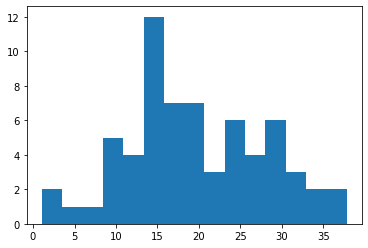

```python
_ = plt.hist(harden.GmSc, bins=15)
```

The histogram is slightly normally distributed with a clear peak in the middle and lower frequencies of more extreme values (0-5, 35+)

### 2.5

```python
m = smf.ols("GmSc ~ FGA", data=harden).fit()
m.summary()
```

OLS Regression Results

| Dep. Variable: | GmSc | R-squared: | 0.133 |
| --- | --- | --- | --- |
| Model: | OLS | Adj. R-squared: | 0.119 |
| Method: | Least Squares | F-statistic: | 9.678 |
| Date: | Wed, 08 Feb 2023 | Prob (F-statistic): | 0.00280 |
| Time: | 22:13:55 | Log-Likelihood: | -224.11 |
| No. Observations: | 65 | AIC: | 452.2 |
| Df Residuals: | 63 | BIC: | 456.6 |
| Df Model: | 1 |  |  |
| Covariance Type: | nonrobust |  |  |

|  | coef | std err | t | P>\|t\| | [0.025 | 0.975] |
| --- | --- | --- | --- | --- | --- | --- |
| Intercept | 8.8748 | 3.582 | 2.477 | 0.016 | 1.716 | 16.034 |
| FGA | 0.7037 | 0.226 | 3.111 | 0.003 | 0.252 | 1.156 |

| Omnibus: | 0.246 | Durbin-Watson: | 1.902 |
| --- | --- | --- | --- |
| Prob(Omnibus): | 0.884 | Jarque-Bera (JB): | 0.198 |
| Skew: | -0.127 | Prob(JB): | 0.906 |
| Kurtosis: | 2.905 | Cond. No. | 59.4 |

Notes:  
[1] Standard Errors assume that the covariance matrix of the errors is correctly specified.

(a) Intercept: in games where Harden made 0 field goal attempts, his game score is 8.8748

(b) Slope: the games where field goal attempt is larger by one unit have a game score larger by 0.7037 units (on average). The slope is statisically significant, it is extrememly unlikely (p < 0.005) that we'd observe a slope this extreme if the null hypothesis was true.

### 2.6

```python
m = smf.ols("GmSc ~ FG + FGA", data=harden).fit()
m.summary()
```

OLS Regression Results

| Dep. Variable: | GmSc | R-squared: | 0.594 |
| --- | --- | --- | --- |
| Model: | OLS | Adj. R-squared: | 0.581 |
| Method: | Least Squares | F-statistic: | 45.30 |
| Date: | Wed, 08 Feb 2023 | Prob (F-statistic): | 7.49e-13 |
| Time: | 22:06:30 | Log-Likelihood: | -199.48 |
| No. Observations: | 65 | AIC: | 405.0 |
| Df Residuals: | 62 | BIC: | 411.5 |
| Df Model: | 2 |  |  |
| Covariance Type: | nonrobust |  |  |

|  | coef | std err | t | P>\|t\| | [0.025 | 0.975] |
| --- | --- | --- | --- | --- | --- | --- |
| Intercept | 8.9917 | 2.472 | 3.637 | 0.001 | 4.049 | 13.934 |
| FG | 3.0427 | 0.363 | 8.383 | 0.000 | 2.317 | 3.768 |
| FGA | -0.5523 | 0.216 | -2.553 | 0.013 | -0.985 | -0.120 |

| Omnibus: | 0.422 | Durbin-Watson: | 1.943 |
| --- | --- | --- | --- |
| Prob(Omnibus): | 0.810 | Jarque-Bera (JB): | 0.069 |
| Skew: | -0.025 | Prob(JB): | 0.966 |
| Kurtosis: | 3.151 | Cond. No. | 64.3 |

Notes:  
[1] Standard Errors assume that the covariance matrix of the errors is correctly specified.

(a) One more field goal is associated with a 3 point increase in game score, if there is no change in field goal attempts. BetaFG is statistically significant. It is less than .01% likely we'd observe a slope this extreme if the true slope was 0 and there was no relationship between FG and game score.

(c) The FGA slope in model one takes into the account times in which the attempt was successful and a field goal was made. This is why it's likely associated with an increase in game score. However the FGA slope in model two reflects its association with game score if the field goal value remains the same (i.e., an attempt was made but no field goal was made). Since no field goal was made in this scenario, it is likely why it is associated with a decrease in game score when we interpret slope with this multiple regression. The first model includes the indirect effect of FGA on game score (which is actual FG), when we use both variables we untangle these effects to only see direct effects of FG and FGA.

(d) R-squared is 0.594. It is quite a bit higher than the R-squared of model 1 which only explained about 13% of the variance in the data. This model is much more predictive, it explains about 60% of the variance in the data. This means that adding FG as a regressor strongly increased the predictive power of our model. In other words, we have a better model with the inclusion of FG and its relationship with game score.

### 2.7

```python
m = smf.ols("GmSc ~ FG + FGA + Q('3PA') + Q('3P') + FT + FTA + ORB + DRB + AST + STL + BLK + TOV + PF", data=harden).fit()
m.summary()
```

OLS Regression Results

| Dep. Variable: | GmSc | R-squared: | 1.000 |
| --- | --- | --- | --- |
| Model: | OLS | Adj. R-squared: | 1.000 |
| Method: | Least Squares | F-statistic: | 3.577e+30 |
| Date: | Wed, 08 Feb 2023 | Prob (F-statistic): | 0.00 |
| Time: | 22:14:19 | Log-Likelihood: | 2013.3 |
| No. Observations: | 65 | AIC: | -3999. |
| Df Residuals: | 51 | BIC: | -3968. |
| Df Model: | 13 |  |  |
| Covariance Type: | nonrobust |  |  |

|  | coef | std err | t | P>\|t\| | [0.025 | 0.975] |
| --- | --- | --- | --- | --- | --- | --- |
| Intercept | 3.197e-14 | 8.51e-15 | 3.757 | 0.000 | 1.49e-14 | 4.91e-14 |
| FG | 2.4000 | 8.32e-16 | 2.88e+15 | 0.000 | 2.400 | 2.400 |
| FGA | -0.7000 | 5.5e-16 | -1.27e+15 | 0.000 | -0.700 | -0.700 |
| Q('3PA') | -2.97e-15 | 9.36e-16 | -3.173 | 0.003 | -4.85e-15 | -1.09e-15 |
| Q('3P') | 1.0000 | 1.42e-15 | 7.02e+14 | 0.000 | 1.000 | 1.000 |
| FT | 1.4000 | 1.59e-15 | 8.82e+14 | 0.000 | 1.400 | 1.400 |
| FTA | -0.4000 | 1.31e-15 | -3.05e+14 | 0.000 | -0.400 | -0.400 |
| ORB | 0.7000 | 1.2e-15 | 5.86e+14 | 0.000 | 0.700 | 0.700 |
| DRB | 0.3000 | 5.64e-16 | 5.32e+14 | 0.000 | 0.300 | 0.300 |
| AST | 0.7000 | 4.54e-16 | 1.54e+15 | 0.000 | 0.700 | 0.700 |
| STL | 1.0000 | 1.29e-15 | 7.74e+14 | 0.000 | 1.000 | 1.000 |
| BLK | 0.7000 | 1.82e-15 | 3.84e+14 | 0.000 | 0.700 | 0.700 |
| TOV | -1.0000 | 7.64e-16 | -1.31e+15 | 0.000 | -1.000 | -1.000 |
| PF | -0.4000 | 1e-15 | -3.99e+14 | 0.000 | -0.400 | -0.400 |

| Omnibus: | 2.005 | Durbin-Watson: | 2.323 |
| --- | --- | --- | --- |
| Prob(Omnibus): | 0.367 | Jarque-Bera (JB): | 1.799 |
| Skew: | 0.403 | Prob(JB): | 0.407 |
| Kurtosis: | 2.876 | Cond. No. | 182. |

Notes:  
[1] Standard Errors assume that the covariance matrix of the errors is correctly specified.

(a) The standard errors are all extremely small while most of the t values are very large.

(b) R-squared is 1 in this model, it tells us that using all of these independent numerical variables as regressors explains 100% of the variance in the data. As such, game score is likely calculated from all these values.

(c) Turnover has a slope of -1, this means that if everything else stays the same, in games with one more turnover we observe a 1 point decrease in game score. This means turnover is bad, and tends to impact game score the worst out of all of the variables (most negative slope).

### 2.8

All of our values (slopes) match the game score formula except for field goals made. I got a slope of 2.4 for field goals made which does not match the game score weight of 0.4.

# Q3.Interpret regression results in the literature

### 3.1

The slope of having a partner is -0.47. This means that having a partner is associated with better mental health. If all other variables stay the same, having a parter is associated with a 0.47 decrease in depression score than those who do not. The effect is not statistically signficant. There is a 15% chance of observing a slope this extreme if the true slope was 0 (i.e., there's no relationship between having a partner and mental health.

### 3.2

The slope of COVID-19 exposure is 0.24. This means that COVID-19 exposure is not associated with better/is worsening mental health. If all other variables stay the same, COVID-19 exposure is associated with a 0.24 increase in depression score than those who do not. The effect is not statistically signficant. There is a 12.9% chance of observing a slope this extreme if the true slope was 0 (i.e., there's no relationship between COVID-19 exposure and mental health.

### 3.3

The slope of financial stress is 2.32. This means that financial stress is associated with worse mental health. If all other variables stay the same, financial stress is associated with a 2.32 increase in depression score than those who do not. The effect is statistically signficant. There is less than a 0.1% chance of observing a slope this extreme if the true slope was 0 (i.e., we reject the null hypothesis that there is no relationship between financial stress and mental health).

# Time Spent

I spent about 8 hours on this assignment